# Ford GoBike System Data Exploration

## Introduction

This document explores a data set that includes information about individual rides made in a bike-sharing system covering the greater San Francisco Bay area in (2019).

- Preliminary Wrangling
- Univariate Exploration
- Bivariate Exploration
- Multivariate Exploration
- Conclusions

<a id= PreliminaryWrangling ></a>

## Preliminary Wrangling

This document explores a dataset including time, stations, and users' attributes

```python
# import all packages and set plots to be embedded inline
import numpy as np
import pandas as pd
import matplotlib.pyplot as plt
import seaborn as sb

%matplotlib inline
```

> Load the dataset and describe its properties

```python
bike_df = pd.read_csv('fordgobike_clean1.csv')
```

```python
bike_df.sample(10)
```

|  | duration_sec | start_time | end_time | start_station_name | end_station_name | bike_id | user_type | member_birth_year | member_gender | bike_share_for_all_trip |
| --- | --- | --- | --- | --- | --- | --- | --- | --- | --- | --- |
| 67135 | 482 | 2019-02-20 08:13:57.164 | 2019-02-20 08:21:59.352 | San Francisco Caltrain Station 2 (Townsend St... | 11th St at Bryant St | 5008 | Subscriber | NaN | NaN | No |
| 160791 | 719 | 2019-02-05 16:30:31.548 | 2019-02-05 16:42:30.602 | Berry St at 4th St | The Embarcadero at Steuart St | 2694 | Subscriber | 1978.0 | Female | No |
| 16810 | 334 | 2019-02-27 08:07:04.964 | 2019-02-27 08:12:39.703 | 5th St at Virginia St | San Fernando St at 4th St | 5895 | Subscriber | 1994.0 | Male | Yes |
| 177372 | 185 | 2019-02-01 22:44:47.652 | 2019-02-01 22:47:53.446 | Downtown Berkeley BART | Fulton St at Bancroft Way | 703 | Subscriber | 1996.0 | Female | Yes |
| 135028 | 511 | 2019-02-08 16:03:09.873 | 2019-02-08 16:11:41.481 | 5th St at Folsom | Market St at Franklin St | 4911 | Customer | 1967.0 | Male | No |
| 84000 | 874 | 2019-02-17 19:13:30.307 | 2019-02-17 19:28:04.532 | Powell St BART Station (Market St at 4th St) | Sanchez St at 15th St | 43 | Subscriber | 1989.0 | Male | No |
| 134330 | 829 | 2019-02-08 17:28:29.707 | 2019-02-08 17:42:18.806 | Folsom St at 9th St | Howard St at Beale St | 4998 | Subscriber | 1985.0 | Male | Yes |
| 117494 | 147 | 2019-02-11 21:33:40.904 | 2019-02-11 21:36:08.697 | North Berkeley BART Station | West St at University Ave | 5094 | Subscriber | 1986.0 | Male | No |
| 50636 | 844 | 2019-02-21 18:47:53.317 | 2019-02-21 19:01:57.512 | Ninth St at Heinz Ave | Russell St at College Ave | 5786 | Subscriber | 1985.0 | Male | No |
| 74182 | 267 | 2019-02-19 11:20:49.530 | 2019-02-19 11:25:16.779 | Salesforce Transit Center (Natoma St at 2nd St) | 2nd St at Townsend St | 6253 | Subscriber | 1971.0 | Male | No |

```python
bike_df.shape
```

```
(183412, 10)
```

```python
# clean the dataset by changing some columns to the following datatypes
# to datetime
bike_df.start_time = pd.to_datetime(bike_df.start_time)
bike_df.end_time = pd.to_datetime(bike_df.end_time)
# to object/string
bike_df.bike_id = bike_df.bike_id.astype('str')

# to category
bike_df.user_type = bike_df.user_type.astype('category')
```

```python
bike_df.info()
```

```
<class 'pandas.core.frame.DataFrame'>
RangeIndex: 183412 entries, 0 to 183411
Data columns (total 10 columns):
duration_sec               183412 non-null int64
start_time                 183412 non-null datetime64[ns]
end_time                   183412 non-null datetime64[ns]
start_station_name         183215 non-null object
end_station_name           183215 non-null object
bike_id                    183412 non-null object
user_type                  183412 non-null category
member_birth_year          175147 non-null float64
member_gender              175147 non-null object
bike_share_for_all_trip    183412 non-null object
dtypes: category(1), datetime64[ns](2), float64(1), int64(1), object(5)
memory usage: 12.8+ MB
```

### What is the structure of your dataset?

after the dataset was cleaned, I was left with **183412** rows and 10 columns:

- duration_sec (int).
- start_time (datetime).
- end_time (datetime).
- start_station_name (object)
- end_station_name (object)
- bike_id (object)
- user_type (category)
- member_birth_year
- member_gender
- bike_share_for_all_trip(object)

### What is/are the main feature(s) of interest in your dataset?

the main feature of interest for this exploration is where are most trips taken, at what time and by who

- start time : what time do people prefer when going out for bike riding
- start_station_name: where is the most popular start station
- user type and member gender: which category uses bikes more

### What features in the dataset do you think will help support your investigation into your feature(s) of interest?

- All remaining features, since not neeeded columns were dropped during the cleaning process.

lets separate the days, months and hour of the start time into new columns and also change the duration seconds to minutes. This will make it easier to explore the data

```python
# new useful columns

#start_time broken down into months, days and hours
bike_df['start_month'] = bike_df.start_time.dt.month
bike_df['start_day'] = bike_df.start_time.dt.weekday
bike_df['start_hour'] = bike_df.start_time.dt.hour

# from end_time
bike_df['end_hour'] = bike_df.end_time.dt.hour

# from duration_sec to duration_minutes
bike_df['duration_minutes'] = bike_df['duration_sec']/60

# 2. Create ages
bike_df['age'] = bike_df['member_birth_year'].apply(lambda x: 2019 - x)

# test
bike_df.head()
```

|  | duration_sec | start_time | end_time | start_station_name | end_station_name | bike_id | user_type | member_birth_year | member_gender | bike_share_for_all_trip | start_month | start_day | start_hour | end_hour | duration_minutes | age |
| --- | --- | --- | --- | --- | --- | --- | --- | --- | --- | --- | --- | --- | --- | --- | --- | --- |
| 0 | 52185 | 2019-02-28 17:32:10.145 | 2019-03-01 08:01:55.975 | Montgomery St BART Station (Market St at 2nd St) | Commercial St at Montgomery St | 4902 | Customer | 1984.0 | Male | No | 2 | 3 | 17 | 8 | 869.750000 | 35.0 |
| 1 | 42521 | 2019-02-28 18:53:21.789 | 2019-03-01 06:42:03.056 | The Embarcadero at Steuart St | Berry St at 4th St | 2535 | Customer | NaN | NaN | No | 2 | 3 | 18 | 6 | 708.683333 | NaN |
| 2 | 61854 | 2019-02-28 12:13:13.218 | 2019-03-01 05:24:08.146 | Market St at Dolores St | Powell St BART Station (Market St at 4th St) | 5905 | Customer | 1972.0 | Male | No | 2 | 3 | 12 | 5 | 1030.900000 | 47.0 |
| 3 | 36490 | 2019-02-28 17:54:26.010 | 2019-03-01 04:02:36.842 | Grove St at Masonic Ave | Central Ave at Fell St | 6638 | Subscriber | 1989.0 | Other | No | 2 | 3 | 17 | 4 | 608.166667 | 30.0 |
| 4 | 1585 | 2019-02-28 23:54:18.549 | 2019-03-01 00:20:44.074 | Frank H Ogawa Plaza | 10th Ave at E 15th St | 4898 | Subscriber | 1974.0 | Male | Yes | 2 | 3 | 23 | 0 | 26.416667 | 45.0 |

<a id= UnivariateExploration ></a>

## Univariate Exploration

exploration with one variable

#### What is the average duration of bike rides?

plot a histogram for the duration

```python
def x_y_t(xL,yL,title):
    plt.title(title)
    plt.xlabel(xL)
    plt.ylabel(yL)
    color = sb.color_palette()[2]
```

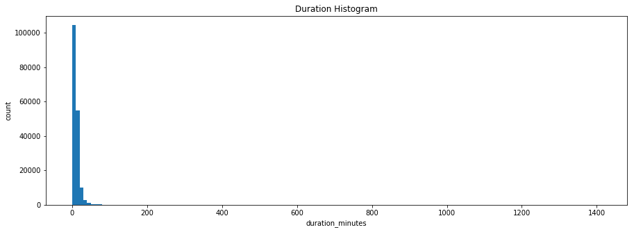

```python
plt.figure(figsize=[15,5])
bin_edges = np.arange(0, bike_df.duration_minutes.max()+10, 10)
plt.hist(data = bike_df, x = 'duration_minutes', bins = bin_edges)
x_y_t('duration_minutes','count','Duration Histogram')
```

as we can see there is a long tail to this histogram meaning that there are alot of point with low values. we therefore need the log scale transformation

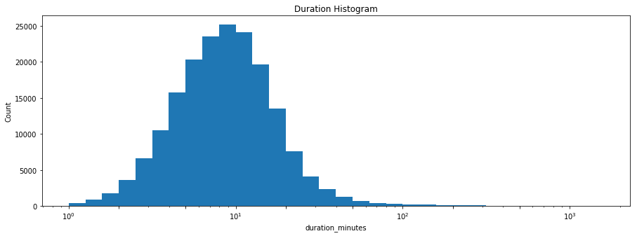

```python
# histogram with logarithmic scale transformation
plt.figure(figsize=[15,5])
bin_edges = 10 ** np.arange(0.0, np.log10(bike_df.duration_minutes.max())+0.1, 0.1)
plt.hist(data = bike_df, x = 'duration_minutes', bins = bin_edges)
plt.xscale('log')
tick_locs = [1, 2, 5, 10, 20, 50, 100, 200, 500, 1000]
plt.xticks(tick_locs)
x_y_t('duration_minutes','Count','Duration Histogram')
```

Most trips lasted for less than an hour as seen in the visualizations above.

### start_time

plot histograms for start day and hour we do not plot for start month as the data set seems to be for the month of february alone

```python
bike_df.start_month.nunique()
```

```
1
```

we do not plot for start month as the data set seems to be for the month of february alone

```python
# labels to use in plots for days
day_labels = ['Mon', 'Tue', 'Wed', 'Thu', 'Fri', 'Sat', 'Sun']

# color to use in plots
base_color = sb.color_palette()[0]
```

#### Which day is the most popular for starting bike rides?

```python
bike_df.start_day.value_counts()
```

```
3    35197
1    31813
2    29641
4    28981
0    26852
6    15523
5    15405
Name: start_day, dtype: int64
```

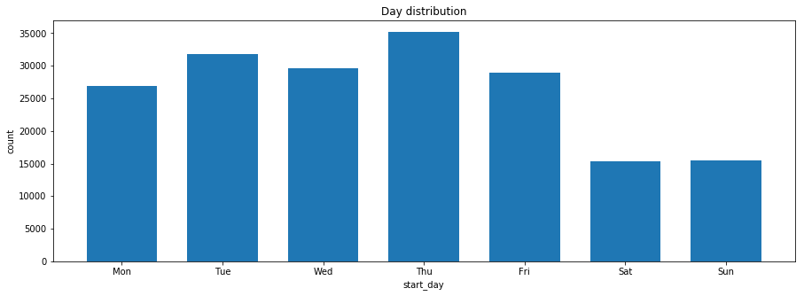

```python
# plot a histogram for days with gaps between bars
plt.figure(figsize=[15,5])
bin_edges = np.arange(-0.5, 6.5+1, 1)
plt.hist(data = bike_df, x = 'start_day', bins = bin_edges, rwidth = 0.7)
plt.xticks(np.arange(0, 6+1, 1), day_labels)
x_y_t('start_day','count','Day distribution')
```

Contrary to what i believed the most popular days to begin rides were not the weekends and are actually weekdays, to be specific Thursday and Tuesday

#### At what time did most trips begin?

```python
bike_df.start_hour.value_counts()
```

```
17    21864
8     21056
18    16827
9     15903
16    14169
7     10614
19     9881
15     9174
12     8724
13     8551
10     8364
14     8152
11     7884
20     6482
21     4561
6      3485
22     2916
23     1646
0       925
5       896
1       548
2       381
4       235
3       174
Name: start_hour, dtype: int64
```

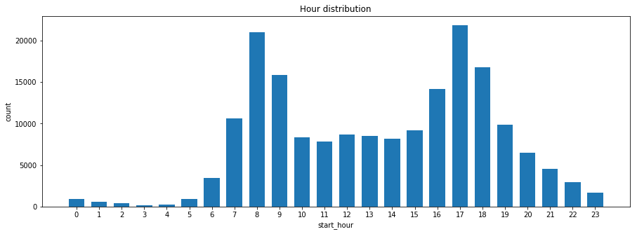

```python
# plot a histogram with gaps between bars
plt.figure(figsize=[15,5])
bin_edges = np.arange(-0.5, 23.5+1, 1)
plt.hist(data = bike_df, x = 'start_hour', bins = bin_edges, rwidth = 0.7)
plt.xticks(np.arange(0, 23+1, 1))
x_y_t('start_hour','count','Hour distribution')
```

most people began their trips early in the morning (around 8 am) or in the evening (around 5 pm)

#### At time did most trips end?

```python
bike_df.end_hour.value_counts()
```

```
17    21295
8     19782
18    18264
9     17684
16    13179
19    10730
10     8977
15     8835
7      8779
12     8617
13     8522
14     8157
11     7587
20     6922
21     4866
22     3240
6      2967
23     1834
0      1003
5       759
1       566
2       422
4       236
3       189
Name: end_hour, dtype: int64
```

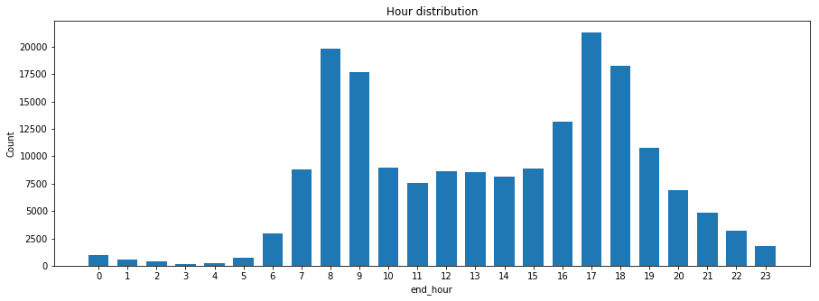

```python
# plot a histogram with gaps between bars
plt.figure(figsize=[15,5])
bin_edges = np.arange(-0.5, 23.5+1, 1)
plt.hist(data = bike_df, x = 'end_hour', bins = bin_edges, rwidth = 0.7)
plt.xticks(np.arange(0, 23+1, 1))
x_y_t('end_hour','Count','Hour distribution')
```

most people ended their trips early in the morning (around 8 am) or in the evening (around 5 pm). there seems to be a relationship between the start time and end time

#### Who went on more trips as compared to the others?

*User_type and Member_gender*

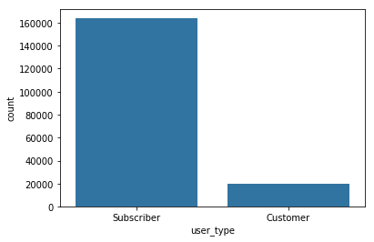

```python
# plot a bar chart
user_type_order = bike_df['user_type'].value_counts().index
sb.countplot(data = bike_df, x = 'user_type', color = base_color, order = user_type_order);
```

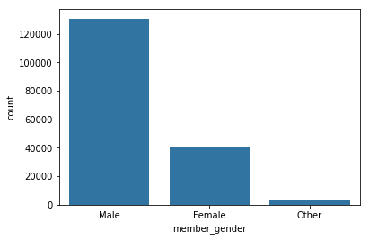

```python
# plot a bar chart
member_gender_order = bike_df['member_gender'].value_counts().index
sb.countplot(data = bike_df, x = 'member_gender', color = base_color, order = member_gender_order);
```

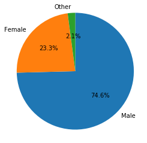

```python
# plot a pie chart
sorted_counts = bike_df['member_gender'].value_counts()
plt.pie(sorted_counts, labels = sorted_counts.index, startangle = 90,
        counterclock = False, autopct='%1.1f%%');
plt.axis('square');
```

subscribes are more likey to go on rides as compared to customers. men go on more rides as compared to women and other

#### What was the most popular start station?

there are alot of stations so we will work with the top 10 stations

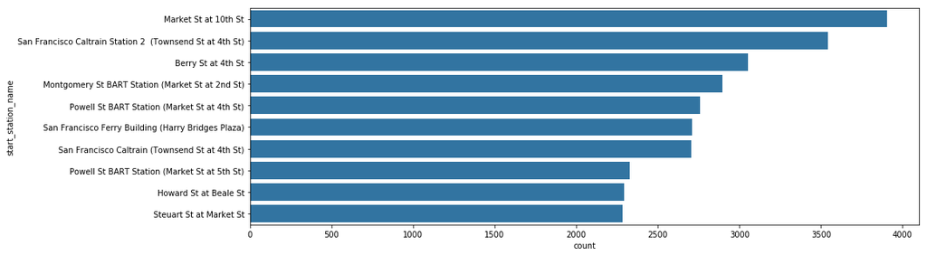

```python
# plot a horizontal bar chart
start_order = bike_df['start_station_name'].value_counts().index[:10]
plt.figure(figsize=[15,5])
sb.countplot(data = bike_df, y = 'start_station_name', color = base_color, order = start_order);
```

the most popular start stations are **Market St at 10th St** and **San Francisco Caltrain Station 2 (Townsend St at 4th St)**

#### What was the most popular end station?

there are alot of stations so we will use the top 10 stations

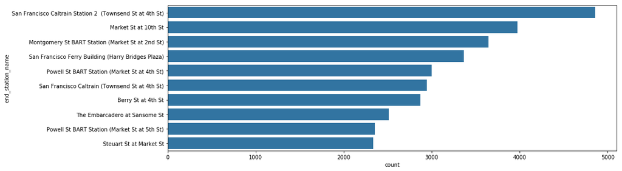

```python
# plot a horizontal bar chart
end_order = bike_df['end_station_name'].value_counts().index[:10]
plt.figure(figsize=[15,5])
sb.countplot(data = bike_df, y = 'end_station_name', color = base_color, order = end_order);
```

the most popular end stations are **San Francisco Caltrain Station 2 (Townsend St at 4th St)** and **Market St at 10th St**

#### What is the average age distribution of most riders

first we need to delete the null values in the age column then plot the age distribution

```python
bike_df.age.isnull().any()
```

```
True
```

```python
bike_df.dropna(subset=['age'], inplace = True)
bike_df.age.isnull().any()
```

```
False
```

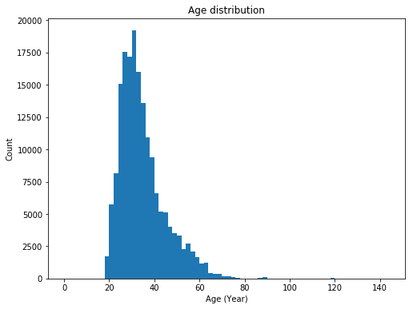

```python
plt.figure(figsize=(8,6))
bins = np.arange(0, bike_df['age'].max()+5, 2)
plt.hist(data=bike_df, x='age', bins=bins)
x_y_t('Age (Year)','Count','Age distribution')
```

this histogram is rightly skewed therefore we need to plot a alogarithimic graph for age

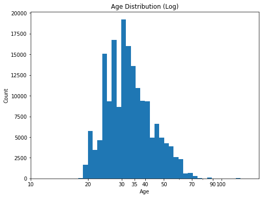

```python
log_binsize = 0.025
bins = 10 ** np.arange(1.2, np.log10(bike_df['age'].max())+log_binsize, log_binsize)

plt.figure(figsize=[8, 6])
plt.hist(data = bike_df, x = 'age', bins = bins)
plt.xscale('log')
plt.xticks([10,20,30,35,40,50,70,90,100], [10,20,30,35,40,50,70,90,100])
x_y_t('Age','Count','Age Distribution (Log)')
```

bike rides seem to be popular among people in their thirties as compared to the other age groups.

### Discuss the distribution(s) of your variable(s) of interest. Were there any unusual points? Did you need to perform any transformations?

start_time

Based on the day: most rides were on Thursdays and Tuesdays. the days with the least amount of rides were Saturday and Sunday Based on starting hour: the distribution is roughly bimodal (has two peaks) at 8 am and 5pm.

end_time Based on ending hour: the distribution is roughly bimodal (has two peaks) at 8 am and 5pm. This could be because most rides didt last more than an hour.

### Of the features you investigated, were there any unusual distributions? Did you perform any operations on the data to tidy, adjust, or change the form of the data? If so, why did you do this?

yes there were some operations done to tidy up the dataset: new columns were crated:

- from start_time - start_hour, start_day and start_hour
- from end_time - end_hour
- duration seconds converted to minutes For the gender groups, there is a 'Other' category. Before I confirm the information, I will keep them in the dataset.

<a id= BivariateExploration ></a>

## Bivariate Exploration

#### Reationship between User Type, Start Day and Start Hour

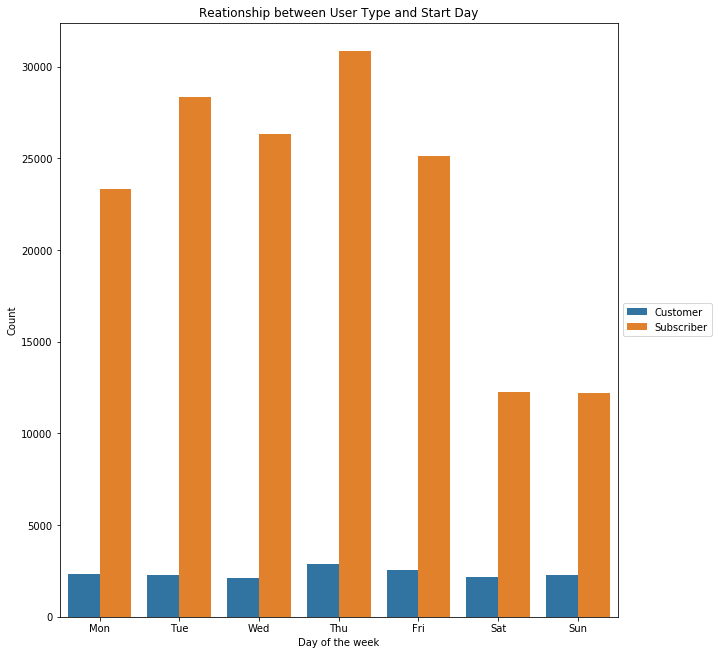

```python
fig = plt.figure(figsize=(10,10))
plt.subplots_adjust(top=0.95)
sb.countplot(data=bike_df, x='start_day', hue='user_type')
plt.legend(loc='center left', bbox_to_anchor=(1,0.5))
plt.xticks(np.arange(0, 6+1, 1), day_labels)
x_y_t('Day of the week','Count','Reationship between User Type and Start Day')
```

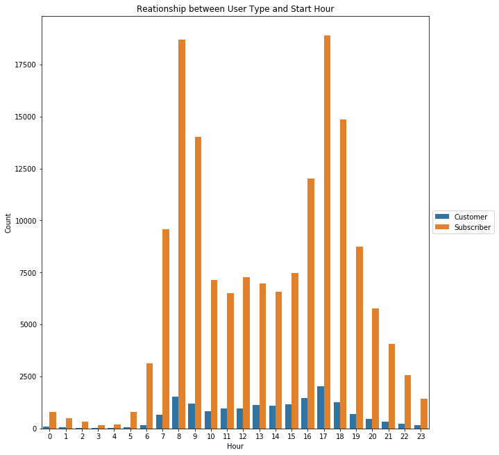

```python
fig = plt.figure(figsize=(10,10))
plt.subplots_adjust(top=0.95)
sb.countplot(data=bike_df, x='start_hour', hue='user_type')
plt.legend(loc='center left', bbox_to_anchor=(1,0.5))
x_y_t('Hour','Count','Reationship between User Type and Start Hour')
```

We can see that subscribers and customers mostly rode bikes early in the morning at 8am or in the evening at 5pm, however the subscribers were more than the customers.

#### Reationship between Gender, Start Day and Start Hour

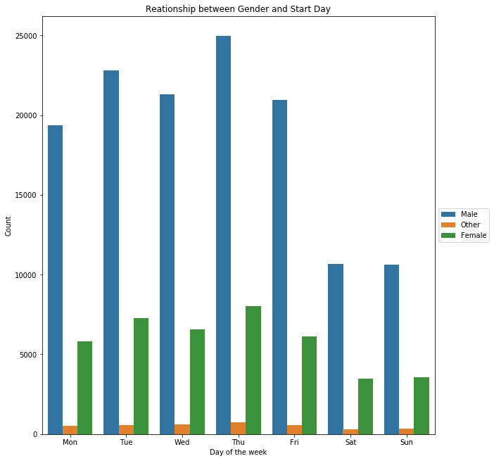

```python
fig = plt.figure(figsize=(10,10))
plt.subplots_adjust(top=0.95)
sb.countplot(data=bike_df, x='start_day', hue='member_gender')
plt.legend(loc='center left', bbox_to_anchor=(1,0.5))
plt.xticks(np.arange(0, 6+1, 1), day_labels)
x_y_t('Day of the week','Count','Reationship between Gender and Start Day')
```

in the bar chart above, all the groups had their trips mostly on Thursdays although the males were more on all days of the week

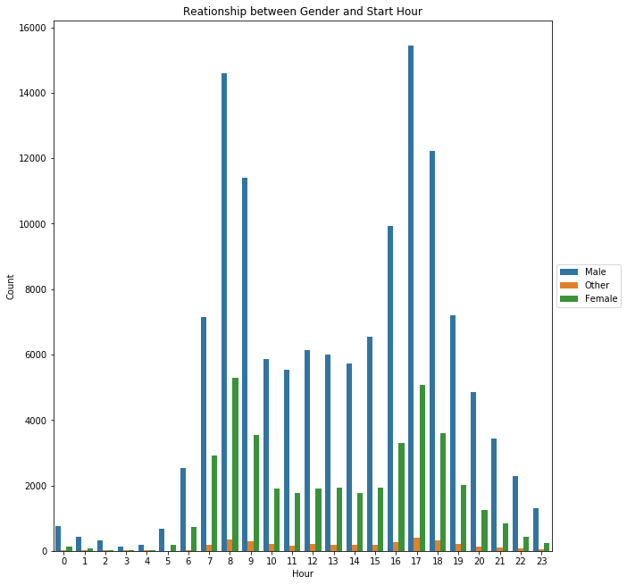

```python
fig = plt.figure(figsize=(10,10))
plt.subplots_adjust(top=0.95)
sb.countplot(data=bike_df, x='start_hour', hue='member_gender')
plt.legend(loc='center left', bbox_to_anchor=(1,0.5))
x_y_t('Hour','Count','Reationship between Gender and Start Hour')
```

Males followed by females mostly rode bikes early in the morning at 8am or in the evening at 5pm, however the other gender mostly rode at 5pm.

#### Reationship between Age and Duration

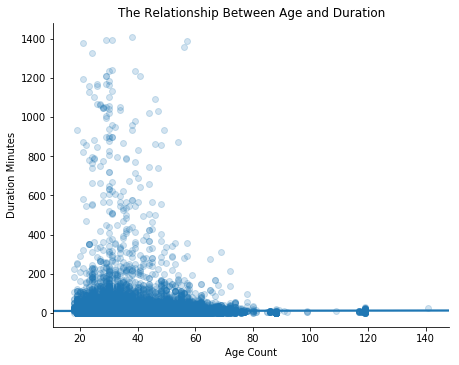

```python
sb.lmplot(x="age",
           y="duration_minutes",
           data=bike_df,
           size = 5,
           aspect=1.3,
           scatter_kws={'alpha':1/5});
x_y_t('Age Count','Duration Minutes','The Relationship Between Age and Duration')
```

#### Reationship between Start Station, Start Day and User Type

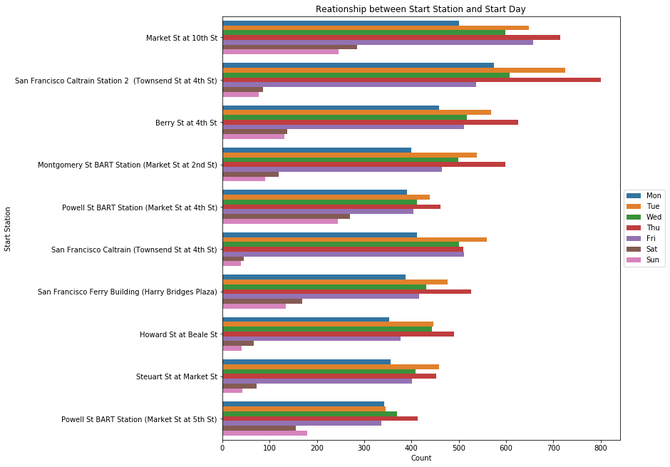

```python
start_order = bike_df['start_station_name'].value_counts().index[:10]
fig = plt.figure(figsize=(10,10))
plt.subplots_adjust(top=0.95)
sb.countplot(data=bike_df, y='start_station_name', hue='start_day', order = start_order)
plt.legend(['Mon', 'Tue', 'Wed', 'Thu', 'Fri', 'Sat', 'Sun'], loc='center left', bbox_to_anchor=(1,0.5))
x_y_t('Count','Start Station','Reationship between Start Station and Start Day')
```

the most popular station( Market St at 10th St) had the most traffic on Thursday. the other top stations also hasd the most traffic on either Tuesday or Thursday.

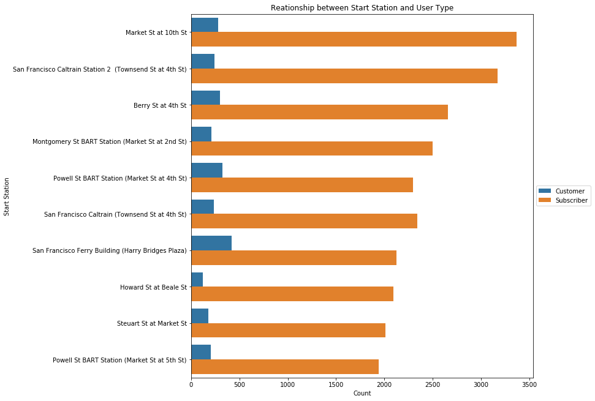

```python
start_order = bike_df['start_station_name'].value_counts().index[:10]
fig = plt.figure(figsize=(10,10))
plt.subplots_adjust(top=0.95)
sb.countplot(data=bike_df, y='start_station_name', hue='user_type', order = start_order)
plt.legend(loc='center left', bbox_to_anchor=(1,0.5))
x_y_t('Count','Start Station','Reationship between Start Station and User Type')
```

The most frequent user types at the popular stations were the subscribers.

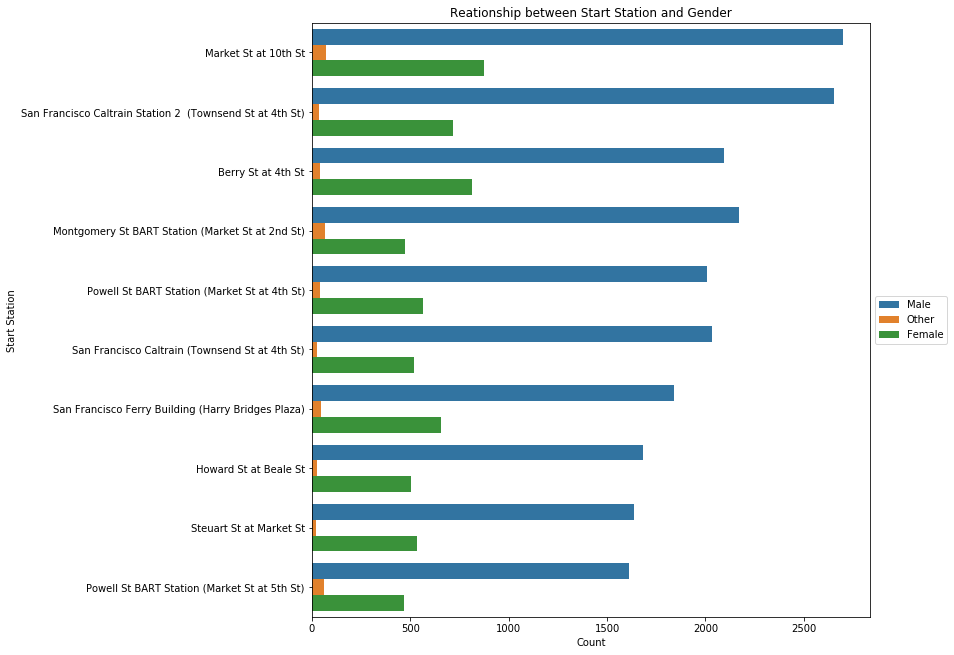

```python
start_order = bike_df['start_station_name'].value_counts().index[:10]
fig = plt.figure(figsize=(10,10))
plt.subplots_adjust(top=0.95)
sb.countplot(data=bike_df, y='start_station_name', hue='member_gender', order = start_order)
plt.legend(loc='center left', bbox_to_anchor=(1,0.5))
x_y_t('Count','Start Station','Reationship between Start Station and Gender')
```

From the visualization above, we can see that the most frequent gender at the popular start stations was male.

#### Relationship Between Duration And Start Day

```python
!pip install -U seaborn
```

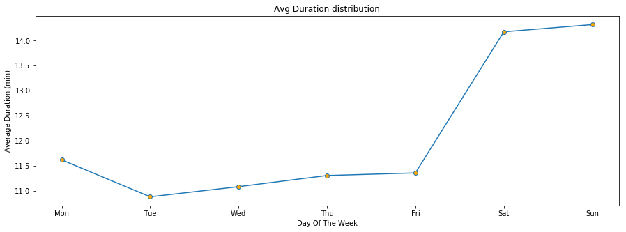

```python
df_clean_60_or_less = bike_df[bike_df.duration_minutes <= 60]
weekday_avg_mint = bike_df.groupby('start_day').duration_minutes.mean()

# plot a line plot
plt.figure(figsize=[15,5])
plt.errorbar(x=weekday_avg_mint.index, y=weekday_avg_mint,marker='o', markerfacecolor='orange');
plt.xticks(np.arange(0,7), day_labels)
x_y_t('Day Of The Week','Average Duration (min)','Avg Duration distribution')
```

#### Relationship Between Start Station, Age and Duration

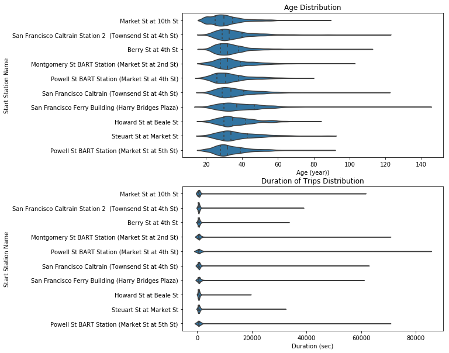

```python
start_order = bike_df['start_station_name'].value_counts().index[:10]
plt.figure(figsize=(8,10))
base_color = sb.color_palette()[0]
ax = plt.subplot(211)
sb.violinplot(data=bike_df, y='start_station_name', x='age', inner='quartile', order = start_order, color=base_color)
x_y_t('Age (year))','Start Station Name','Age Distribution')

ax = plt.subplot(212)
sb.violinplot(data=bike_df, y='start_station_name', x='duration_sec', inner='quartile', order = start_order, color=base_color)
x_y_t('Duration (sec)','Start Station Name','Duration of Trips Distribution')
```

From the plots above we see that bike riding seems to be popular among people in the thirties.  
On average rides on the weekend (Saturday and Sunday) lasted longer than the other days.

### Talk about some of the relationships you observed in this part of the investigation. How did the feature(s) of interest vary with other features in the dataset?

**Subscribers and customers :**

Subscribers and customers mostly rode bikes early in the morning at 8am or in the evening at 5pm, however the subscribers were more than the customers.  
Both groups had their trips mostly on Thursdays  
**Member genders and :**

Males followed by females mostly rode bikes early in the morning at 8am or in the evening at 5pm, however the other gender mostly rode at 5pm.  
All the groups had their trips mostly on Thursdays

**Start Station:** the most popular station( Market St at 10th St) had the most traffic on Thursday. the other top stations also hasd the most traffic on either Tuesday or Thursday.  
The most frequent user types were the subscribers.  
The most frequent gender were the males.

**Age:**

Bike riding seems to be popular among people in the thirties.

### Did you observe any interesting relationships between the other features (not the main feature(s) of interest)?

No

<a id= MultivariateExploration ></a>

## Multivariate Exploration

> Create plots of three or more variables to investigate your data even further. Make sure that your investigations are justified, and follow from your work in the previous sections.

#### User Type Average Duration Based on Start Day and Start Hour

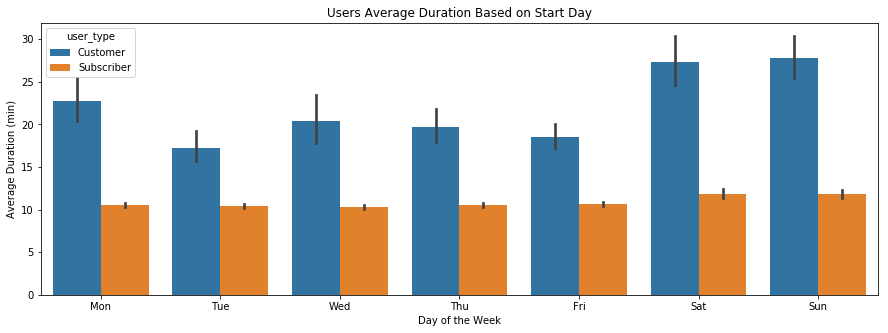

```python
plt.figure(figsize=[15,5])
sb.barplot(x="start_day",y="duration_minutes", hue ="user_type", data=bike_df);

plt.xticks(np.arange(0,7), day_labels)
x_y_t('Day of the Week','Average Duration (min)','Users Average Duration Based on Start Day')
```

Subscriber and Customer rides lasted longer on Saturday and Sunday.  
we can see that customer rides lasted longer than subscriber rides.  
On average customers rides lasted longer than subscribers rides on every week day.

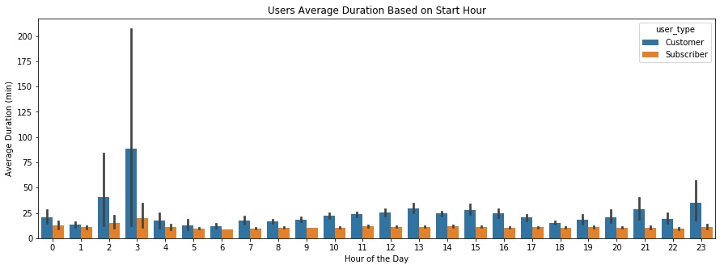

```python
plt.figure(figsize=[15,5])
sb.barplot(x="start_hour",y="duration_minutes", hue ="user_type", data=bike_df);

plt.xticks(np.arange(0,24))
x_y_t('Hour of the Day','Average Duration (min)','Users Average Duration Based on Start Hour')
```

Subscriber and Customer had longer rides at 2 or 3 am.This could be because the bikes rented at this time were probably returned the next day  
On average customers rides lasted longer than subscribers rides at every hour of the day.

#### Member Gender Average Duration Based On Start Day And Start Hour

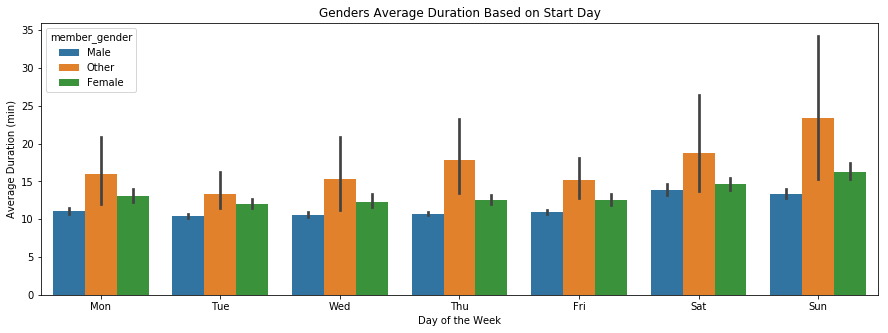

```python
plt.figure(figsize=[15,5])
sb.barplot(x="start_day",y="duration_minutes", hue ="member_gender", data=bike_df);

plt.xticks(np.arange(0,7), day_labels)
x_y_t('Day of the Week','Average Duration (min)','Genders Average Duration Based on Start Day')
```

[figure not shown]

```python
plt.figure(figsize=[15,5])
sb.barplot(x="start_hour",y="duration_minutes", hue ="member_gender", data=bike_df);

plt.xticks(np.arange(0,24))
x_y_t('Day of the Week','Average Duration (min)','Genders Average Duration Based on Start Hour')
```

Other and females had longer rides at 2 or 3 am. On average other rides lasted longer than male and female rides at most hours of the day (except at 9-10 am and at 6pm).

### Were there any interesting or surprising interactions between features?

Yes, customers were more likely to use bikes for a longer period than subscribers.